# Data Wrangling & EDA

# Background Information and Objective

Understanding what drives customers to buy organic products is key as in many segments the market growth of organic products is outstripping that of the overall segment. Organic products also represent billions of dollars in sales and the availability of orgnic products is a key factor in why some consumers pick one grocery store over another.

A recent report from the Organic Trade Association stated that the U.S. market for organic products was $52.2 billion and accounted for 5.7% of all food sales in the United States in 2018. They reported that the majority of organic food sales were fruits and vegetables, accounting for $17.4 billion in sales; dairy and eggs made up the second-largest organic food category at $6.5 billion in sales. Sales of organic fruits and vegetables grew by 5.6% which far surpassed the growth of the overall fruit and vegetable market at 1.7%. Non-food organic products saw 10.6% overall growth from 2017 to 2018 also surpassing the growth of the overall non-food segment at 3.6% (Redman). And recent polling by IRI, a consumer research company, found that 49% of Millennials and 40% of Gen X shoppers consider having a good selection of natural and organic foods important in selecting a grocery store (Emarketer).

For this project, we are acting as a team of analysts that is interested in identifying households and baskets that are likely to buy organic products so we know who to target for an organic product marketing campaign. In order to do this, we will use data at both the household and basket level and try classification models to accurately identify these households. We are also interested in organic trends over time and will use a classification model to attempt to flag households who have increased their spending on organic products in year two.

(Citations Redman, Russell. “Organic Products Hit a Record-Breaking High.” Supermarket News (May 20, 2019). https://search-proquest-com.proxy.libraries.uc.edu/docview/2238503079?accountid=2909.)

Emarketer - Data is from the January 2020 IRI report titled “Consumer Connect Q4 2019: Channel Trends in CPG Today.” 2,366 US internet users ages 18+ were surveyed online during December 2019. https://chart-na1.emarketer.com/234160/attributes-us-internet-users-find-important-store-selection-process-by-generation-dec-2019-of-respondents-each-group

# The Data

The data set we are using for our project is called “The Complete Journey 2.0” and it is found on the 84.51 website. This data set has transactions at the household level from a group of 5,000 households over a two year period. This is a relational data set comprised of household data, transaction data, and product data that can be combined by household and product IDs. The household data has demographic information such as the size, income, and age of the household. The transaction data contains information like the amount of money spent and the number of items in a transaction. The product data contains information like the product category, whether a product is organic, and whether the product is a private or national brand.

## Household Data Set

The majority of households fall between the ages of 35 and 74 and the distribution of age appears to be fairly normal with the exception of the very low number of households in the 19-24 range. This could be due to the fact that many younger shoppers still use their parent’s loyalty card, so their data could show up under their parent’s age. The vast majority of households are owners as opposed to renters and the majority of households also have a loyalty card. Income is slightly skewed right with fewer households making above $75,000. Many households in the data set are also comprised of only two adults, or two adults with one child.

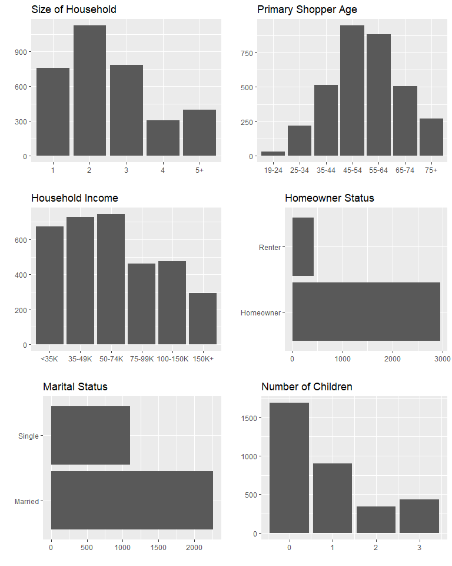

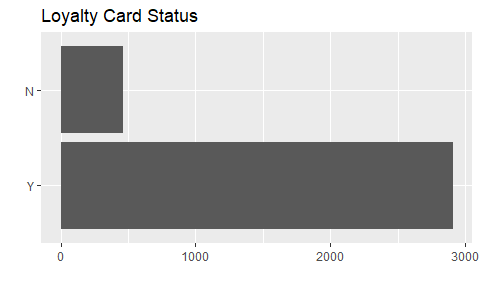

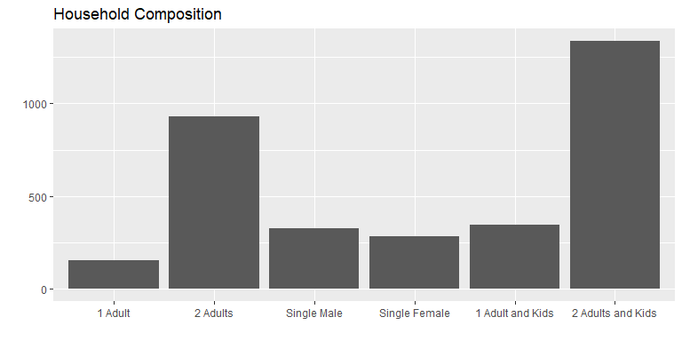

## Products Data Set

The products data set has 151,141 observations and 5 variables which give information about the product. Each product has a unique ‘PRODUCT_NUM’ that links it to the transaction data set. Information such as the product department (food, non-food, or pharmacy), whether the product is a private or national brand, whether the product is organic, and the commodity of the product can be found in this data set. Product commidity is the most detailed information given about a given product so while we cannot pinpoint specific brands in this data set, we can see which categories of products are being bought organic.

## Transactions Data Set

The transactions data set has 10,625,553 observations and 9 variables which give detailed information about every transaction over a two year period. Both the households and products data sets can be linked to the transaction set by the ‘HSHD_NUM’ and ‘PRODUCT_NUM’ keys. Information such as the date of purchase, the amount spent and number of units purchased, and store region can be found in this data set.

# Feature Engineering

## Household Purchasing of Organic Products

## Market Basket

```r
#to use later
#res <- lapply( mydf , function(x) rbind( mean = mean(x) ,
 #                                 sd = sd(x) ,
  #                                median = median(x) ,
   #                               minimum = min(x) ,
    #                              maximum = max(x) ,
     #                             s.size = length(x) ) )
```

```r
#save out created datasets to work with in future

setwd(paths[Sys.info()[7]])
```

[output not shown]

```r
save(market_basket, file = "market_basket.Rdata", compress = FALSE)
save(organic_households, file = "organic_households.Rdata", compress = FALSE)
save(household_increase, file = "household_increase.Rdata", compress = FALSE)

#should be able to use function "load(file = "organic_households.Rdata")" to load dataset when you need it in a different notebook
```

```r
summary(organic_households)
```

[output not shown]

## Daily SPEND Prediction

```r
# merge data by "HSHD_NUM" and "PRODUCT_NUM"
merge_df <- merge(transactions,products,by="PRODUCT_NUM")
merge_df <- merge(merge_df,households,by="HSHD_NUM")
str(merge_df)
```

```r
# set HSHD_NUM/PRODUCT_NUM /BASKET_NUM to interger variable
merge_df[sapply(merge_df, is.character)] <- lapply(merge_df[sapply(merge_df, is.character)],as.integer)
```

```r
# filter Organic transactions and split by YEAR
organic <- merge_df%>%filter(ORGANIC=="Y")
organic_2016 <- organic%>%filter(YEAR=="2016")
organic_2017 <- organic%>%filter(YEAR=="2017")

# check "organic_2016" structure
str(organic_2016)
```

```r
# check range of "organic_2016$WEEK_NUM"
summary(organic_2016$WEEK_NUM)
```

```r
# set "organic_2016$WEEK_NUM" as factor
organic_2016$WEEK_NUM <- as.factor(organic_2016$WEEK_NUM)
```

```r
# check range of "organic_2017$WEEK_NUM"
summary(organic_2017$WEEK_NUM)
```

```r
# set "organic_2017$WEEK_NUM" as factor
organic_2017$WEEK_NUM <- as.factor(organic_2017$WEEK_NUM)

# reset organic_2017$WEEK_NUM level as 1:52
levels(organic_2017$WEEK_NUM) <- seq(1,52,1)
levels(organic_2017$WEEK_NUM)
```

```r
# aggregate data by "WEEK_NUM"
organic_SPEND_week_2016 <- organic_2016%>%group_by(WEEK_NUM)%>%
  summarise(SPEND_SUM_16=sum(SPEND),          # total spend(can be view as total revenue) for each week
            SPEND_AVG_16=mean(SPEND),        # average spend(can be view as average revenue) for each week
            TRAN_NUM_16=n())%>%
  mutate(WEEK_NUM=as.integer(WEEK_NUM))

organic_SPEND_week_2017 <- organic_2017%>%group_by(WEEK_NUM)%>%
  summarise(SPEND_SUM_17=sum(SPEND),          # total spend(can be view as total revenue) for each week
            SPEND_AVG_17=mean(SPEND),        # average spend(can be view as average revenue) for each week
            TRAN_NUM_17=n())%>%
  mutate(WEEK_NUM=as.integer(WEEK_NUM))

organic_SPEND_week_2016
organic_SPEND_week_2017
```

```r
# bar chart Weekly Agregate SPEND each year
library(ggplot2)
ggplot(organic_SPEND_week_2016,aes(WEEK_NUM,SPEND_SUM_16))+geom_bar(stat = "identity")+
  ggtitle("Organic Weekly Agregate SPEND - 2016")

ggplot(organic_SPEND_week_2017,aes(WEEK_NUM,SPEND_SUM_17))+geom_bar(stat = "identity")+
  ggtitle("Organic Weekly Agregate SPEND - 2017")
```

[output not shown]

```r
# combine Weekly Agregate SPEND in a data set
organic_SPEND_week <- merge(organic_SPEND_week_2016,organic_SPEND_week_2017,by="WEEK_NUM")
organic_SPEND_week
```

```r
# Organic Weekly Agregate SPEND_SUM
ggplot(organic_SPEND_week, aes(WEEK_NUM)) +
  geom_line(aes(y = SPEND_SUM_16, colour = "SPEND_SUM_16")) +
  geom_line(aes(y = SPEND_SUM_17, colour = "SPEND_SUM_17"))+
  theme(legend.position="bottom")+
  ggtitle("Organic Weekly Agregate SPEND_SUM")
```

[output not shown]

```r
# Organic Weekly Agregate SPEND_AVG
ggplot(organic_SPEND_week, aes(WEEK_NUM)) +
  geom_line(aes(y = SPEND_AVG_16, colour = "SPEND_AVG_16")) +
  geom_line(aes(y = SPEND_AVG_17, colour = "SPEND_AVG_17"))+
  theme(legend.position="bottom")+
  ggtitle("Organic Weekly Agregate SPEND_AVG")
```

[output not shown]

```r
# aggregate data by "DATE"
organic_SPEND_DATE <- organic%>%group_by(DATE)%>%
  summarise(SPEND_SUM=sum(SPEND),          # daily total spend(can be view as total revenue)
            SPEND_AVG=mean(SPEND),        # daily average spend(can be view as average revenue)
            TRAN_NUM=n())

organic_SPEND_DATE
```

```r
# plot daily spend

library(latticeExtra)

# --> construct separate plots for each series
obj1 <- xyplot(SPEND_SUM ~ DATE, organic_SPEND_DATE, type = "l" , lwd=2)
obj2 <- xyplot(SPEND_AVG ~ DATE, organic_SPEND_DATE, type = "l", lwd=2)

# --> Make the plot with second y axis AND legend:
doubleYScale(obj1, obj2, text = c("SPEND_SUM_daily", "SPEND_AVG_daily") , add.ylab2 = TRUE)
```

[output not shown]

# Idea from the SPEND Time Series Plots